# Lab 2 Sample Response

Ryan Miller

## Setup

```r
#install.packages("ggplot2")
library(ggplot2)
```

## Question 1

```r
## Begin by reading in the data
colleges19 <- read.csv("https://remiller1450.github.io/data/Colleges2019.csv")

## Print the dimensions
dim(colleges19)
```

```
## [1] 1658   22
```

There are 1658, each is a different US college that serves primarily undergrads and has more than 400 students.

## Question 2

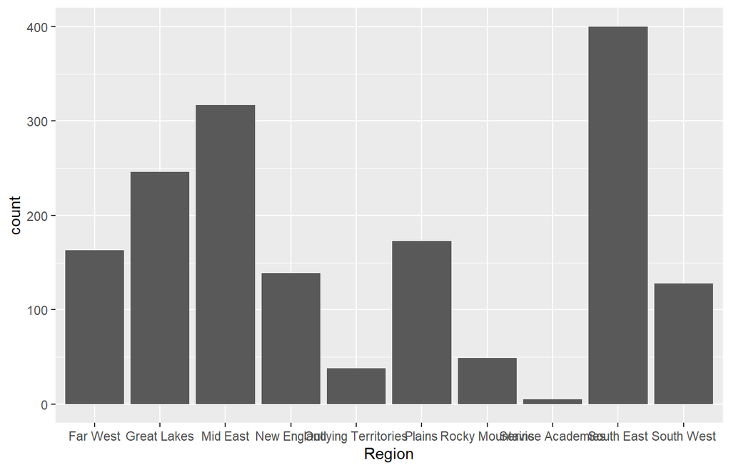

```r
ggplot(colleges19, aes(x = Region)) + geom_bar()
```

It might be interesting to see how colleges are distributed geographically.

## Question 3

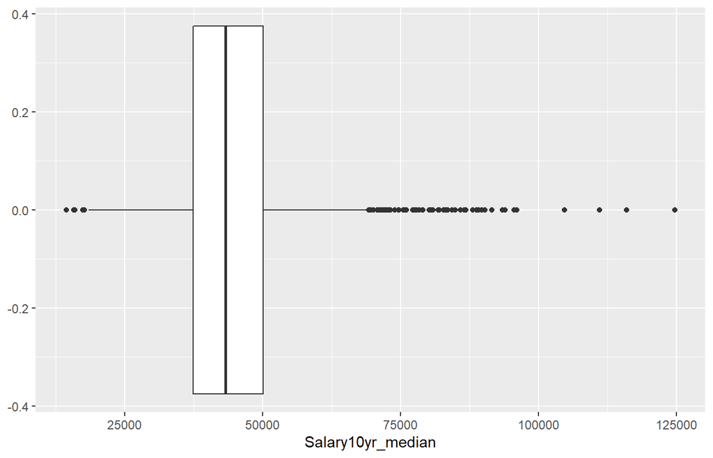

```r
ggplot(colleges19, aes(x = Salary10yr_median)) + geom_boxplot()
```

A large number of people go to college because it will benefit their future income, so it’s interesting to see how much variety there is across different schools.

## Question 4

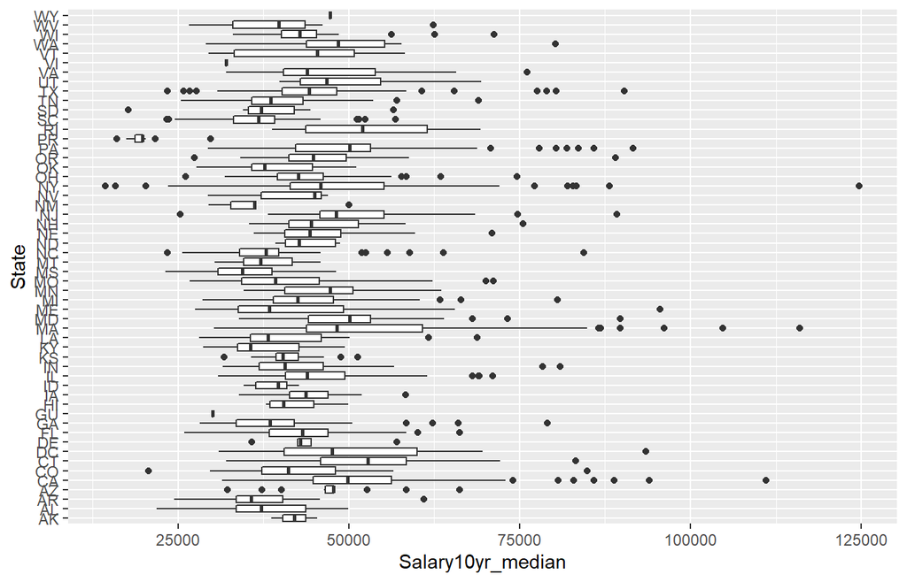

```r
## Example 1
ggplot(colleges19, aes(x = Salary10yr_median, y = State)) + geom_boxplot()
```

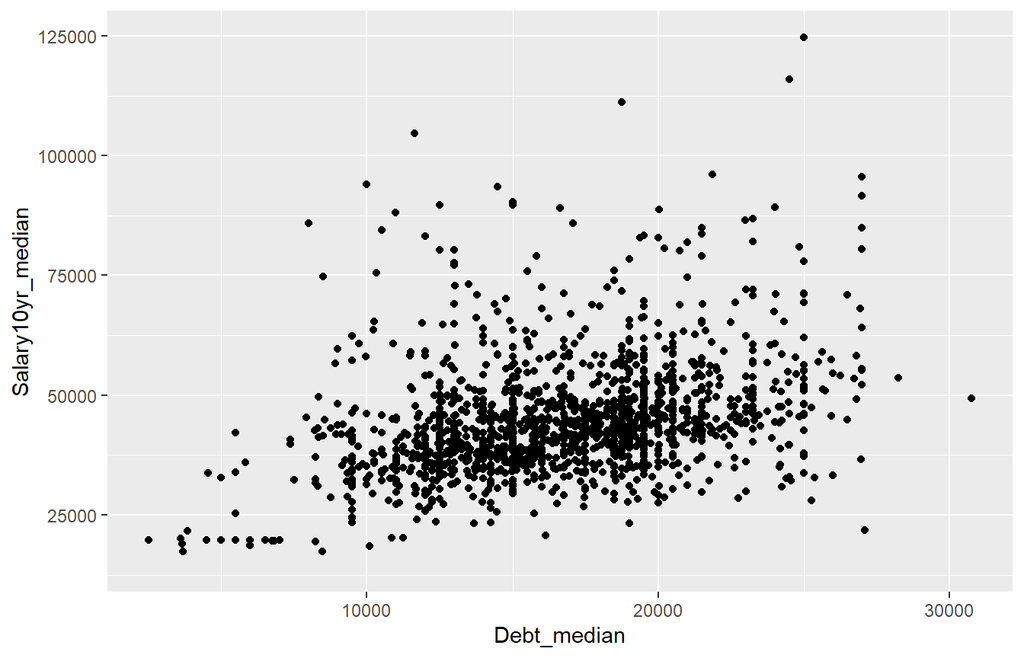

```r
## Example #2
ggplot(colleges19, aes(x = Debt_median, y = Salary10yr_median)) + geom_point()
```

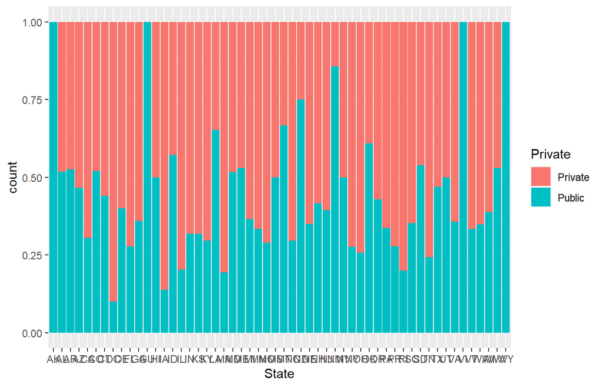

```r
## Example #3
ggplot(colleges19, aes(x = State, fill = Private)) + geom_bar(position = "fill")
```

1. Median salaries tend to vary according to the state a college is located in.
2. There appears to be a positive association between a school’s median student debt and its students’ future salary.
3. Private schools are more common in most states, but some states like WY, AK, etc. only have public schools.

## Question 5

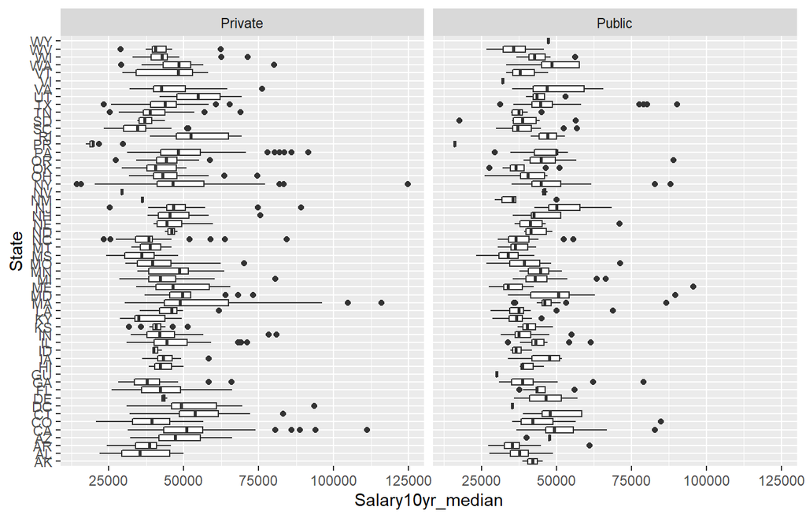

```r
## Example 1
ggplot(colleges19, aes(x = Salary10yr_median, y = State)) + geom_boxplot() + facet_wrap(~Private)
```

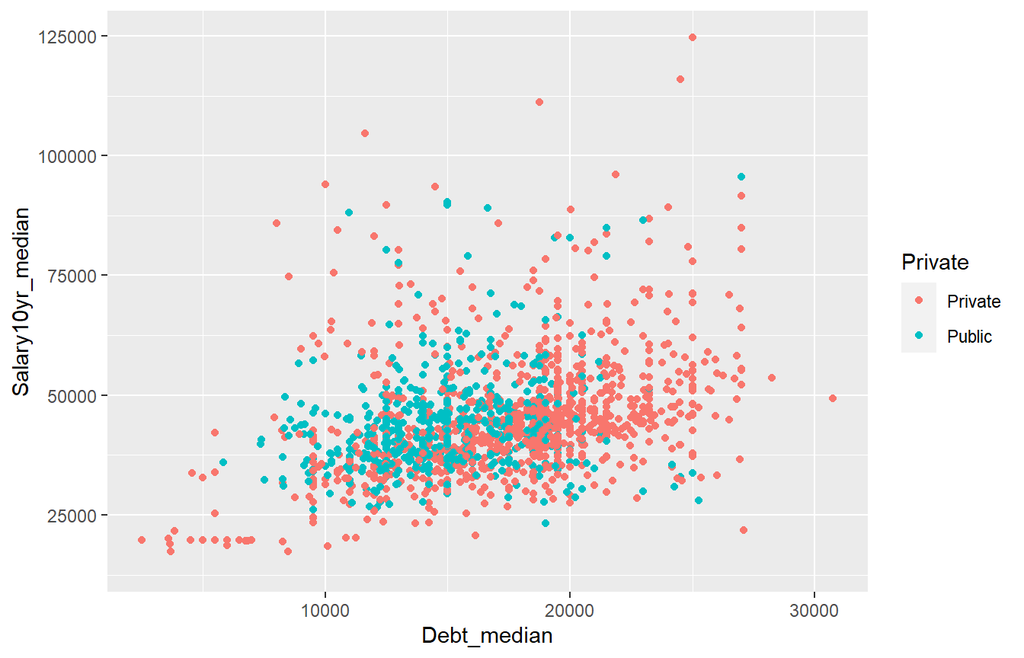

```r
## Example #2
ggplot(colleges19, aes(x = Debt_median, y = Salary10yr_median, col = Private)) + geom_point()
```

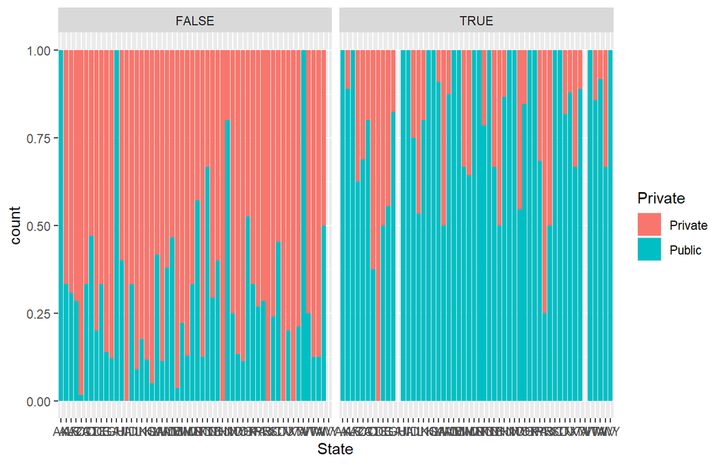

```r
## Example #3 - Note - I used a logical condition to create a categorical variable here
ggplot(colleges19, aes(x = State, fill = Private)) + geom_bar(position = "fill") + facet_wrap(~Enrollment > 5000)
```

## Question 6

```r
## Example #1
OH <- colleges19[colleges19$State == "OH", ]
IN <- colleges19[colleges19$State == "IN", ]

summary(OH$Salary10yr_median)
```

```
##    Min. 1st Qu.  Median    Mean 3rd Qu.    Max.
##   26100   39500   42600   43471   46250   74600
```

```r
summary(IN$Salary10yr_median)
```

```
##    Min. 1st Qu.  Median    Mean 3rd Qu.    Max.    NA's
##   31500   36875   40650   43360   46250   80900       4
```

```r
## Example #1 (stratified)
OH_priv <- colleges19[colleges19$State == "OH" & colleges19$Private == "Private", ]
IN_priv <- colleges19[colleges19$State == "IN"& colleges19$Private == "Private", ]

summary(OH_priv$Salary10yr_median)
```

```
##    Min. 1st Qu.  Median    Mean 3rd Qu.    Max.
##   31800   40000   42900   44439   47800   74600
```

```r
summary(IN_priv$Salary10yr_median)
```

```
##    Min. 1st Qu.  Median    Mean 3rd Qu.    Max.    NA's
##   32300   37775   41900   44954   46925   80900       2
```

```r
OH_pub <- colleges19[colleges19$State == "OH" & colleges19$Private == "Public", ]
IN_pub <- colleges19[colleges19$State == "IN"& colleges19$Private == "Public", ]

summary(OH_pub$Salary10yr_median)
```

```
##    Min. 1st Qu.  Median    Mean 3rd Qu.    Max.
##   26100   38000   40500   40682   46100   47100
```

```r
summary(IN_pub$Salary10yr_median)
```

```
##    Min. 1st Qu.  Median    Mean 3rd Qu.    Max.    NA's
##   31500   36275   37450   39642   41450   55100       2
```

```r
## Example #2 (not stratified)
cor(colleges19$Salary10yr_median, colleges19$Debt_median, use = "complete.obs")
```

```
## [1] 0.3528626
```

```r
## Example #2 (stratified)
privates <- colleges19[colleges19$Private == "Private", ]
cor(privates$Salary10yr_median, privates$Debt_median, use = "complete.obs")
```

```
## [1] 0.3835548
```

```r
publics <- colleges19[colleges19$Private == "Public", ]
cor(publics$Salary10yr_median, publics$Debt_median, use = "complete.obs")
```

```
## [1] 0.2620458
```

```r
## Example #3 (not stratified)
table(colleges19$State, colleges19$Private)
```

```
##
##      Private Public
##   AK       0      2
##   AL      13     14
##   AR       9     10
##   AZ       8      7
##   CA      73     32
##   CO      12     13
##   CT      14     11
##   DC       9      1
##   DE       3      2
##   FL      39     15
##   GA      32     18
##   GU       0      1
##   HI       3      3
##   IA      25      4
##   ID       3      4
##   IL      47     12
##   IN      30     14
##   KS      15      7
##   KY      19      8
##   LA       8     15
##   MA      54     13
##   MD      14     15
##   ME       8      9
##   MI      26     15
##   MN      24     12
##   MO      32     13
##   MS       8      8
##   MT       3      6
##   NC      38     16
##   ND       2      6
##   NE      13      7
##   NH       7      5
##   NJ      20     13
##   NM       1      6
##   NV       3      3
##   NY      92     35
##   OH      49     17
##   OK       9     14
##   OR      12      9
##   PA      77     39
##   PR      26     10
##   RI       8      2
##   SC      22     12
##   SD       6      7
##   TN      28      9
##   TX      44     39
##   UT       4      4
##   VA      27     15
##   VI       0      1
##   VT       6      3
##   WA      15      8
##   WI      22     14
##   WV       8      9
##   WY       0      1
```

```r
## Example #3 (stratified)
table(colleges19$State, colleges19$Private, colleges19$Enrollment > 5000)
```

```
## , ,  = FALSE
##
##
##      Private Public
##   AK       0      1
##   AL      12      6
##   AR       9      4
##   AZ       5      2
##   CA      59      1
##   CO      10      5
##   CT       9      8
##   DC       4      1
##   DE       2      1
##   FL      31      5
##   GA      29      4
##   GU       0      1
##   HI       3      2
##   IA      25      0
##   ID       2      1
##   IL      40      4
##   IN      28      6
##   KS      15      2
##   KY      19      1
##   LA       7      5
##   MA      47      6
##   MD      13      8
##   ME       8      7
##   MI      26      1
##   MN      21      6
##   MO      27      4
##   MS       8      4
##   MT       3      4
##   NC      35      5
##   ND       2      4
##   NE      12      5
##   NH       6      4
##   NJ      18      0
##   NM       1      4
##   NV       3      1
##   NY      72     11
```

[output cut: 62 more lines]

```
##   PA       6     13
##   PR       6      2
##   RI       2      2
##   SC       0      5
##   SD       0      2
##   TN       2      9
##   TX       4     29
##   UT       2      4
##   VA       1      8
##   VI       0      0
##   VT       0      1
##   WA       1      6
##   WI       1     11
##   WV       1      2
##   WY       0      1
```

1. The median college’s 10 year post-graduation salary is slightly higher for OH than IN. If we stratify to separate private and public schools, the median is higher for OH among public schools, but not much higher for private schools.
2. A school’s median student debt has a positive correlation with it’s median 10-year student income. This correlation is stronger for private schools.
3. 30/44 = 68.2% of colleges in IN are private, while 49/66 = 74.2$% of colleges in OH are private. Interestingly, 2/10 large schools (enrollment > 5000) in IN are private (Notre Dame and Indiana Wesleyan), while 2/11 large schools in OH are private (Case Western and Dayton).